# Coursera Capstone Project Week 2 Report

Carto Wong

September 5, 2016

# Dataset

We will use the [capstone dataset](https://d396qusza40orc.cloudfront.net/dsscapstone/dataset/Coursera-SwiftKey.zip) provided by SwiftKey. The files are named LOCALE.SOURCE.txt where LOCALE is the each of the four locales *en_US*, *de_DE*, *ru_RU* and *fi_FI*, and SOURCE is *blogs*, *news*, or *twitter*. The data is from a corpus called HC Corpora. See the readme file at http://www.corpora.heliohost.org/aboutcorpus.html for details on the corpora available. The files have been language filtered but may still contain some foreign text.

For this report, we use the following 3 files:

- en_US.blogs.txt
- en_US.news.txt
- en_US.twitter.txt

# Sampling from the text documents

The basic summary of the 3 files is as follow.

| File | Number of lines | Size |
| --- | --- | --- |
| en_US.blogs.txt | 899,288 | 200.4 MB |
| en_US.news.txt | 1,010,242 | 196.3 MB |
| en_US.twitter.txt | 2,360,148 | 159.4 MB |

Due to the size of these files, we will use only a small subset of the data. For each of these file, we will keep approximately 10% of the lines. Below is the script that we use to generate the sample files.

```r
# Read the input file line by line. For each line, write it to the output file with probability p.
sampleText <- function(inputFilePath, outputFilePath, p) {

  set.seed(26) # for reproducibility

  lines <- readLines(inputFilePath)
  sampleLines <- sample(lines, size = p * length(lines))
  writeLines(sampleLines, outputFilePath)
}

p <- 0.1
inputDir <- '../rawData/final/en_US'
outputDir <- '../sampleData'
inputFileNames <- c('en_US.blogs.txt', 'en_US.news.txt', 'en_US.twitter.txt')
for (inputFileName in inputFileNames) {
  n <- nchar(inputFileName)
  inputFilePath <- paste(inputDir, inputFileName, sep = '/')
  outputFileName <- paste0(substr(inputFileName, 1, n-4), '.sample', substr(inputFileName, n -3, n))
  outputFilePath <- paste(outputDir, outputFileName, sep = '/')

  if (!file.exists(outputFilePath)) {
    sampleText(inputFilePath, outputFilePath, p)
  }
}
```

Here is a summary for the sample files.

| File | Number of lines | Size |
| --- | --- | --- |
| en_US.blogs.sample.txt | 89,737 | 19.9 MB |
| en_US.news.sample.txt | 100,838 | 19.5 MB |
| en_US.twitter.sample.txt | 235,618 | 15.7 MB |

# Data cleaning and tokenization

We use the `tm` package to clean up the text documents, such as converting to lower case, removing punctuation, and stripping whitespaces.

```r
library(tm)

tokenize <- function(filePath,
                     to.lower = FALSE,
                     remove.punctuation = FALSE,
                     strip.whitespace = FALSE,
                     remove.stopwords = FALSE)
{
  # Read the text file and tokenize it.
  #
  # Args:
  #   filePath {string}
  #            the file path
  #   to.lower {boolean}
  #            Should it convert characters to lower case?
  #   remove.punctuation {boolean}
  #                      Should it remove punctuation?
  #   strip.whitespace   {boolean}
  #                      Should it strip whitespace?
  #   remove.stopwords   {boolean}
  #                      Should it remove stopwords?
  #
  # Returns: {list}
  #          a list with the following properties:
  #          - numLines {int}
  #                     the number of lines
  #          - text     {character}
  #                     the clean text
  #          - tokens   {character}
  #                     a vector of words

  lines <- readLines(filePath)
  text <- paste(lines, collapse = '\n')
  textSource <- VectorSource(text)
  corpus <- Corpus(textSource)

  # Cleaning
  if (to.lower) {
    corpus <- tm_map(corpus, content_transformer(tolower))
  }
  if (remove.punctuation) {
    corpus <- tm_map(corpus, removePunctuation)
  }
  if (strip.whitespace) {
    corpus <- tm_map(corpus, stripWhitespace)
  }
  if (remove.stopwords) {
    corpus <- tm_map(corpus, removeWords, stopwords('english'))
  }

  cleanText <- corpus[[1]]$content
  tokens <- strsplit(cleanText, split = '[^a-z]+')[[1]]

  result = list()
  result$numLines <- length(lines)
  result$text <- cleanText
  result$tokens <- tokens
  result
}

blogs <- tokenize('../sampleData/en_US.blogs.sample.txt',
                  to.lower = TRUE,
                  remove.punctuation = TRUE,
                  strip.whitespace = TRUE)
news <- tokenize('../sampleData/en_US.news.sample.txt',
                  to.lower = TRUE,
                  remove.punctuation = TRUE,
                  strip.whitespace = TRUE)
twitter <- tokenize('../sampleData/en_US.twitter.sample.txt',
                  to.lower = TRUE,
                  remove.punctuation = TRUE,
                  strip.whitespace = TRUE)
```

# Unigrams

Using the tokenization, we compute the word (unigram) frequences for the 3 sample text documents. Below are the most frequent words that we find from the sample documents. Note that a lot of them are stopwords. We keep the stopwords since they will play a role in the n-gram model.

```r
# Combine the tokens from the 3 files and compute the word frequencies.
tokens <- c(blogs$tokens, news$tokens, twitter$tokens)
freq <- sort(table(tokens), decreasing = TRUE)
head(freq, n = 50)
```

```
## tokens
##    the     to    and      a     of     in      i    for     is   that
## 475432 274561 240096 238285 200426 164825 164030 109654 107025 103442
##    you     it     on   with    was     my     at     be   this   have
##  93481  90370  81573  70923  62235  59794  56826  54655  54427  52952
##    are     as    but     he     we    not   from     so     me    its
##  49135  48363  48199  42866  41216  40781  38330  37854  36903  35617
##    all   they     by   will     or   said    his   just   your     an
##  33204  32059  31621  31153  30881  30601  30129  30088  29822  29809
##  about    out     up    one     if   what   like   when    has    who
##  29736  29455  29189  28659  28066  27630  26719  26368  26050  24904
```

## Bigrams

Let us compute the most frequent bigrams.

```r
tokens2 <- c(tokens[-1], '.')
freq2 <- sort(table(paste(tokens, tokens2)), decreasing = TRUE)
head(freq2, n = 50)
```

```
##
##    of the    in the    to the   for the    on the     to be    at the
##     43054     41322     21368     20183     19583     16210     14245
##   and the      in a  with the      is a    it was     for a  from the
##     12583     12082     10561     10092      9573      9524      8774
##     i was    i have     it is     and i    with a  going to      of a
##      8594      8580      8277      8268      8208      8087      7988
##   will be      i am    is the    have a    if you    one of    to get
##      7946      7767      7566      7455      7313      7181      7029
##      as a   want to    by the  that the   have to    i dont   this is
##      6849      6387      6206      6139      6090      6070      5963
##     to do     and a   i think the first     was a      to a    out of
##      5924      5859      5822      5697      5654      5627      5613
##    that i      on a    to see   all the  the same     but i    i love
##      5434      5399      5398      5276      5108      5061      5025
##   to make
##      4776
```

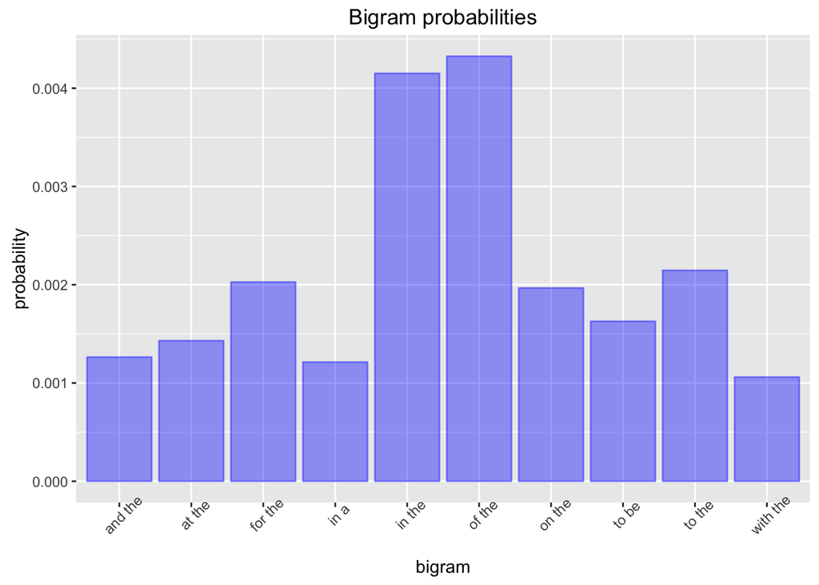

```r
library(ggplot2)

totalFreq2 <- sum(freq2)
df2 <- data.frame(bigram = names(freq2[1:10]), prob = freq2[1:10]/totalFreq2)
ggplot(data = df2, aes(x = bigram, y = prob)) +
  geom_bar(stat = 'identity', color = 'blue', fill = 'blue', alpha = 0.4) +
  ggtitle('Bigram probabilities') +
  xlab('bigram') +
  ylab('probability') +
  theme(axis.text.x = element_text(angle = 45))
```

## Trigrams

Similarly, we compute the frequencies of the trigrams.

```r
tokens3 <- c(tokens2[-1], '.')
freq3 <- sort(table(paste(tokens, tokens2, tokens3)), decreasing = TRUE)
head(freq3, n = 50)
```

```
##
##         one of the           a lot of     thanks for the
##               3451               2982               2389
##            to be a        going to be          i want to
##               1840               1757               1486
##           it was a         the end of         out of the
##               1484               1447               1429
##        some of the         as well as         be able to
##               1401               1398               1280
##        part of the           i have a        i dont know
##               1214               1191               1185
## looking forward to          i have to        the rest of
##               1137               1101               1092
##        is going to     the first time        im going to
##               1040               1027               1026
##        a couple of          this is a       cant wait to
##               1023                970                961
##      thank you for         there is a          i need to
##                959                953                943
##        you want to         i love you        you have to
##                939                935                921
##           to go to         end of the      the fact that
##                888                883                878
##        this is the       in the world       in the first
##                868                862                844
##          to have a          one of my        it would be
##                828                825                811
##         at the end      for the first        in front of
##                810                796                793
##            it is a         you have a   according to the
##                788                783                780
##     for the follow       i dont think         all of the
##                775                775                766
##          is one of        most of the
##                755                754
```

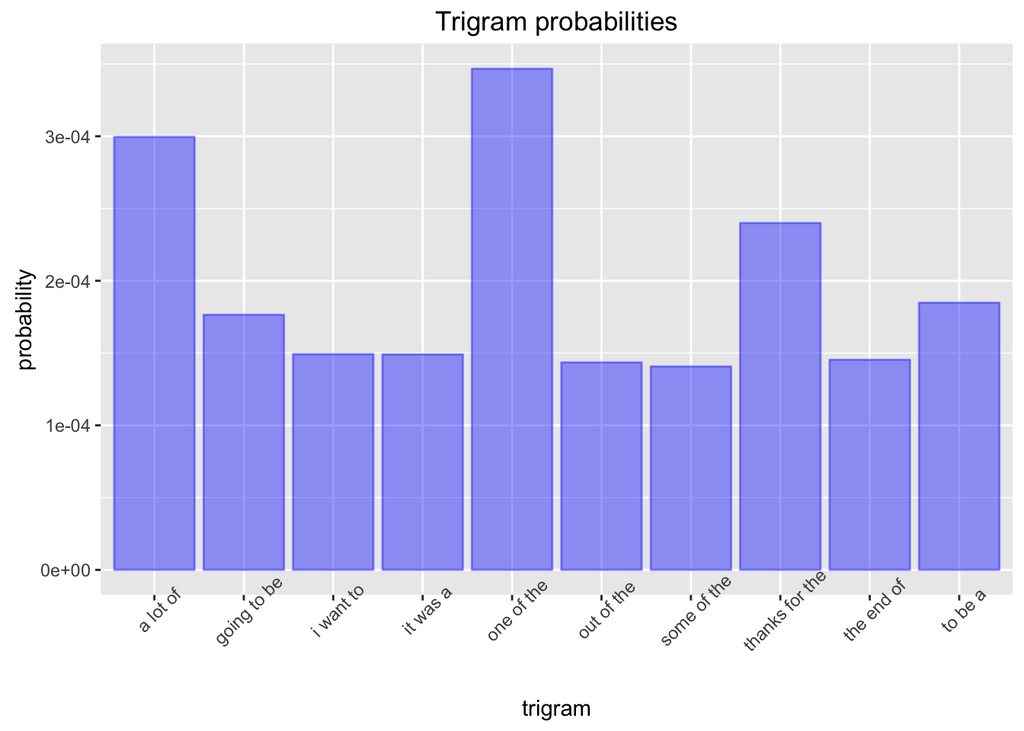

```r
totalFreq3 <- sum(freq3)
df3 <- data.frame(trigram = names(freq3[1:10]), prob = freq3[1:10]/totalFreq3)
ggplot(data = df3, aes(x = trigram, y = prob)) +
  geom_bar(stat = 'identity', color = 'blue', fill = 'blue', alpha = 0.4) +
  ggtitle('Trigram probabilities') +
  xlab('trigram') +
  ylab('probability') +
  theme(axis.text.x = element_text(angle = 45))
```

## Next step

In the next 5 weeks, we will use the n-gram model to implement a text prediction app. The app takes a phrase from the user as input, and predicts the next word using our n-gram probabilities.